# Section C

# Clearing the environment

```r
rm(list = ls())
```

```r
Dataset_Raw = load("section_b.Rda")            #  -> Reading Rda
```

```r
# names(sales)
table(sales$pizza)
```

```
 0  1  2  3  4  5  6  7  8  9 11
 1  2  4  7  8  2  8  4  5  1  1
```

```r
lm_1   <- lm(pizza ~ 1, data=sales)
lm_All <- lm(pizza ~ ., data=sales)
MaxSteps = dim(sales)[2]
scope_parameter <- list(lower = lm_1, upper = lm_All)
StepAIC_Result <- stepAIC(lm_1,
                       direction = 'forward',
                       scope = scope_parameter,
                       steps = MaxSteps)
```

```
Start:  AIC=77.55
pizza ~ 1

              Df Sum of Sq    RSS    AIC
+ weekday      4   101.132 148.03 63.157
+ wraps        1    75.938 173.22 63.916
+ total_sales  1    54.554 194.61 68.921
+ soda         1    33.896 215.27 73.259
+ dessert      1    31.650 217.51 73.705
+ fruitcup     1    25.062 224.10 74.989
+ humidity     1    18.300 230.86 76.267
+ staff        2    23.670 225.49 77.255
<none>                     249.16 77.547
+ pasta        1     9.570 239.59 77.863
+ coffee       1     8.207 240.96 78.107
+ rainfall     1     3.567 245.59 78.927
+ chips        1     1.818 247.34 79.232
+ wind         1     1.391 247.77 79.306
+ temp         1     1.129 248.03 79.352
+ juice        1     0.284 248.88 79.498

Step:  AIC=63.16
pizza ~ weekday

              Df Sum of Sq    RSS    AIC
+ humidity     1   23.2528 124.78 57.809
+ wraps        1    8.7971 139.23 62.523
+ staff        2   13.2335 134.80 63.131
<none>                     148.03 63.157
+ temp         1    5.6867 142.34 63.473
+ fruitcup     1    4.5548 143.48 63.814
+ dessert      1    3.8664 144.16 64.019
+ pasta        1    3.8208 144.21 64.033
+ coffee       1    2.1260 145.91 64.535
+ wind         1    1.6655 146.37 64.671
+ rainfall     1    1.2334 146.80 64.798
+ soda         1    0.7725 147.26 64.932
+ chips        1    0.7165 147.31 64.949
+ juice        1    0.4748 147.56 65.019
+ total_sales  1    0.4226 147.61 65.034
```

[output cut: 71 more lines]

```
Step:  AIC=49.61
pizza ~ weekday + humidity + staff + dessert + total_sales +
    soda

           Df Sum of Sq    RSS    AIC
<none>                  81.712 49.606
+ pasta     1    3.4112 78.301 49.773
+ chips     1    3.3494 78.363 49.807
+ wind      1    1.7992 79.913 50.649
+ coffee    1    1.4966 80.216 50.811
+ rainfall  1    1.1160 80.596 51.015
+ fruitcup  1    0.9729 80.740 51.091
+ wraps     1    0.9671 80.745 51.094
+ temp      1    0.7028 81.010 51.235
+ juice     1    0.0031 81.709 51.605
```

The optimal model is

```r
model1 = lm(pizza ~ weekday + humidity + staff + dessert + total_sales +soda, data = sales)
```

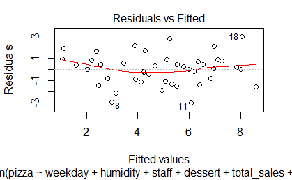

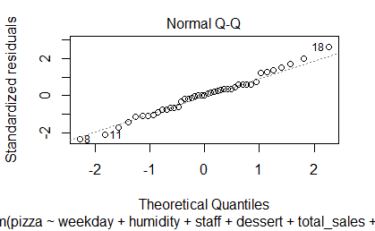

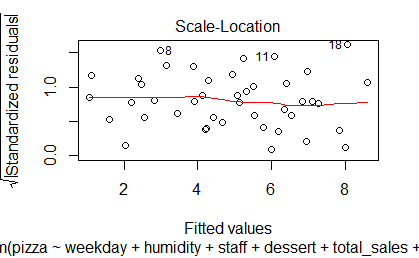

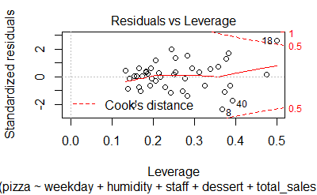

```r
plot(model1)
```

Row 18 is highlighted because it is a observation with high leverage, and it`s ouside of cook`s distance, that means that that observation is most probably an outlier and we should decide how we want to deal with it, since it can change the regression result.

```r
sales[18,]
```

| weekday | staff | pizza | wraps | pasta | dessert | fruitcup | chips | juice | soda | coffee | total_sales | temp | humidity | rainfall | wind |
| --- | --- | --- | --- | --- | --- | --- | --- | --- | --- | --- | --- | --- | --- | --- | --- |
| Thursday | Tom | 11 | 19 | 12 | 9 | 2 | 4 | 2 | 31 | 28 | 180.63 | 28 | 55 | 0 | 9 |

```r
summary(sales)
```

```
   weekday            staff        pizza
 Length:43          Harry:13   Min.   : 0.00
 Class :character   Sara :27   1st Qu.: 3.00
 Mode  :character   Tom  : 3   Median : 4.00
                    Kate : 0   Mean   : 4.86
                               3rd Qu.: 6.50
                               Max.   :11.00
     wraps           pasta
 Min.   : 4.00   Min.   : 0.000
 1st Qu.: 9.00   1st Qu.: 3.000
 Median :13.00   Median : 5.000
 Mean   :13.33   Mean   : 6.023
 3rd Qu.:17.50   3rd Qu.: 8.000
 Max.   :25.00   Max.   :28.000
    dessert          fruitcup
 Min.   : 1.000   Min.   :0.000
 1st Qu.: 3.500   1st Qu.:1.000
 Median : 6.000   Median :2.000
 Mean   : 6.023   Mean   :1.721
 3rd Qu.: 8.500   3rd Qu.:2.000
 Max.   :13.000   Max.   :4.000
     chips            juice             soda
 Min.   : 0.000   Min.   : 0.000   Min.   :12.0
 1st Qu.: 6.500   1st Qu.: 2.500   1st Qu.:21.0
 Median : 9.000   Median : 5.000   Median :29.0
 Mean   : 9.209   Mean   : 5.047   Mean   :29.7
 3rd Qu.:11.000   3rd Qu.: 6.500   3rd Qu.:36.0
 Max.   :25.000   Max.   :21.000   Max.   :55.0
     coffee       total_sales         temp
 Min.   : 4.00   Min.   : 70.0   Min.   :20.00
 1st Qu.:15.00   1st Qu.:120.8   1st Qu.:32.00
 Median :24.00   Median :151.5   Median :36.00
 Mean   :22.21   Mean   :151.3   Mean   :39.93
 3rd Qu.:29.50   3rd Qu.:181.0   3rd Qu.:46.00
 Max.   :48.00   Max.   :240.9   Max.   :76.00
    humidity        rainfall
 Min.   :27.00   Min.   :0.00000
 1st Qu.:48.00   1st Qu.:0.00000
 Median :63.00   Median :0.00000
 Mean   :59.77   Mean   :0.03837
 3rd Qu.:70.00   3rd Qu.:0.00000
 Max.   :85.00   Max.   :0.88000
      wind
 Min.   : 6.00
 1st Qu.:14.00
 Median :16.00
 Mean   :16.63
 3rd Qu.:18.00
 Max.   :30.00
```

```r
RSS = sum((summary(model1)$residuals)^2)
print(RSS)
```

```
[1] 81.71237
```

```r
EstimatedRMSE = sqrt(RSS/(43-11))
print(EstimatedRMSE)
```

```
[1] 1.597971
```

8. Degrees of freedom lost during the regression
9. RMSE the Root Mean Squared Error, since it gives an idea of how high is the root of the mean of the squared distance of the real value from the predicted value.

```r
model_weekday = lm(pizza ~ weekday, data = sales)
summary(model_weekday)
```

```
Call:
lm(formula = pizza ~ weekday, data = sales)

Residuals:
    Min      1Q  Median      3Q     Max
-5.8750 -1.0000 -0.1667  1.1500  5.1250

Coefficients:
                 Estimate Std. Error t value
(Intercept)        2.1667     0.8058   2.689
weekdayMonday      1.3889     1.0402   1.335
weekdayThursday    3.7083     1.0659   3.479
weekdayTuesday     4.5333     1.0192   4.448
weekdayWednesday   2.8333     1.0192   2.780
                 Pr(>|t|)
(Intercept)       0.01058 *
weekdayMonday     0.18977
weekdayThursday   0.00128 **
weekdayTuesday   7.32e-05 ***
weekdayWednesday  0.00841 **
---
Signif. codes:
0 â***â 0.001 â**â 0.01 â*â 0.05 â.â 0.1 â â 1

Residual standard error: 1.974 on 38 degrees of freedom
Multiple R-squared:  0.4059,    Adjusted R-squared:  0.3434
F-statistic:  6.49 on 4 and 38 DF,  p-value: 0.0004402
```

We can see that the level “monday” is the only nbon significant one (at 95% confidence) so it`s coefficient is statistically equal to 0 , the level “Thuesday” is significant to a 99% confidence level,the levl Tuesday is significant to a 99.9% confidence and the level Wednesday is significant to 99% confidence

And when all the dummies considered in the model are = 0, that is the average sales for the day friday (since that is the day that has been left out.)

```r
anova(model_weekday,model1)
```

```
Analysis of Variance Table

Model 1: pizza ~ weekday
Model 2: pizza ~ weekday + humidity + staff + dessert + total_sales +
    soda
  Res.Df     RSS Df Sum of Sq      F   Pr(>F)
1     38 148.031
2     32  81.712  6    66.318 4.3286 0.002635 **
---
Signif. codes:
0 â***â 0.001 â**â 0.01 â*â 0.05 â.â 0.1 â â 1
```

13. The null hypothesis of the anova is H0: The unrestricted model has NO more explanatory power than the restricted model.

Since the p-value of the anova (F-test) is lower than 0.05 we can say that we reject the null hypothesis with a confidence level of 95% That means that the explainatory power of the unrestricted model (model1, from stepwise selection) is better for explaining the dependent variable, than the restricted model (model_weekday)

```r
summary(model1)
```

```
Call:
lm(formula = pizza ~ weekday + humidity + staff + dessert + total_sales +
    soda, data = sales)

Residuals:
     Min       1Q   Median       3Q      Max
-3.06174 -0.99589  0.06394  0.77025  2.96439

Coefficients:
                  Estimate Std. Error t value
(Intercept)      -4.572614   1.878000  -2.435
weekdayMonday     1.699653   1.046001   1.625
weekdayThursday   4.080927   1.242567   3.284
weekdayTuesday    4.984927   1.364267   3.654
weekdayWednesday  3.282669   1.039462   3.158
humidity          0.094753   0.022365   4.237
staffSara         0.790680   0.653504   1.210
staffTom          3.155763   1.203885   2.621
dessert           0.224218   0.089948   2.493
total_sales      -0.020486   0.009864  -2.077
soda              0.059439   0.033714   1.763
                 Pr(>|t|)
(Intercept)      0.020654 *
weekdayMonday    0.113993
weekdayThursday  0.002480 **
weekdayTuesday   0.000916 ***
weekdayWednesday 0.003455 **
humidity         0.000179 ***
staffSara        0.235177
staffTom         0.013293 *
dessert          0.018043 *
total_sales      0.045926 *
soda             0.087441 .
---
Signif. codes:
0 â***â 0.001 â**â 0.01 â*â 0.05 â.â 0.1 â â 1

Residual standard error: 1.598 on 32 degrees of freedom
Multiple R-squared:  0.6721,    Adjusted R-squared:  0.5696
F-statistic: 6.558 on 10 and 32 DF,  p-value: 1.99e-05
```

The model is not of any practical use for predicting pizza sales, because the adjusted Rsqaured is really low, 0.569 and that means that the model can only explain around 60% of the variance of the dependent variable. Also, this adj Rsqaured is calculated using the residuals from the train set data, that means that if we actually test this model on new data ( Test set) we would almost certainly get a lower Rsquared and a lower Adj Rsquared.

15. Because doing cross validation, for n folds, we train the model on n-1 folds and then test it on the “never seen before” data present in the remaining 1 fold, and we repeat this precess for n times leaving out each time a different fold. This process ensures (If we do it for an accurate amount of folds (n)) that we would get a more accurate estimate of the Rsquared adj Rsquared and RMSE parameters, since they would derive by testing the model on actual new data, and not from train set data.
16. This argument repeats the cross validation process for k times, that ensures that even if for some reasons some folds made in the preocess are biased, this bias would disapear by repeating the process k times and then taking the mans results.
17. the maximum number of fold would be the number of rows poresent in the dataset, this CV method is called Leave One Out and it`s computationally very expensive, since we would have to train the model Nrows times

```r
Banana = 10
set.seed(Banana)
regressControl  = trainControl(method="repeatedcv",
                        number = 10,
                        repeats = 100
                        )
Model1_CV    = train(pizza ~  weekday,
               data = sales,
               method  = "lm",
               trControl = regressControl)
```

```
There were missing values in resampled performance measures.
```

```r
Model2_CV    = train(pizza ~  weekday + temp + humidity + wind,
               data = sales,
               method  = "lm",
               trControl = regressControl)
summary(Model1_CV)
```

```
Call:
lm(formula = .outcome ~ ., data = dat)

Residuals:
    Min      1Q  Median      3Q     Max
-5.8750 -1.0000 -0.1667  1.1500  5.1250

Coefficients:
                 Estimate Std. Error t value
(Intercept)        2.1667     0.8058   2.689
weekdayMonday      1.3889     1.0402   1.335
weekdayThursday    3.7083     1.0659   3.479
weekdayTuesday     4.5333     1.0192   4.448
weekdayWednesday   2.8333     1.0192   2.780
                 Pr(>|t|)
(Intercept)       0.01058 *
weekdayMonday     0.18977
weekdayThursday   0.00128 **
weekdayTuesday   7.32e-05 ***
weekdayWednesday  0.00841 **
---
Signif. codes:
0 â***â 0.001 â**â 0.01 â*â 0.05 â.â 0.1 â â 1

Residual standard error: 1.974 on 38 degrees of freedom
Multiple R-squared:  0.4059,    Adjusted R-squared:  0.3434
F-statistic:  6.49 on 4 and 38 DF,  p-value: 0.0004402
```

```r
summary(Model2_CV)
```

```
Call:
lm(formula = .outcome ~ ., data = dat)

Residuals:
    Min      1Q  Median      3Q     Max
-4.7888 -0.8424 -0.0820  0.8908  5.0354

Coefficients:
                 Estimate Std. Error t value
(Intercept)      -0.74564    2.31952  -0.321
weekdayMonday     0.78327    1.02948   0.761
weekdayThursday   3.55925    1.01200   3.517
weekdayTuesday    4.29439    0.98554   4.357
weekdayWednesday  2.71223    0.98797   2.745
temp              0.01370    0.02869   0.477
humidity          0.05997    0.02463   2.434
wind             -0.05896    0.05544  -1.064
                 Pr(>|t|)
(Intercept)       0.74977
weekdayMonday     0.45185
weekdayThursday   0.00123 **
weekdayTuesday    0.00011 ***
weekdayWednesday  0.00948 **
temp              0.63601
humidity          0.02016 *
wind              0.29482
---
Signif. codes:
0 â***â 0.001 â**â 0.01 â*â 0.05 â.â 0.1 â â 1

Residual standard error: 1.855 on 35 degrees of freedom
Multiple R-squared:  0.5164,    Adjusted R-squared:  0.4197
F-statistic:  5.34 on 7 and 35 DF,  p-value: 0.0003198
```